# Could anyone have seen it coming?

Foresight panel v2 — eight catastrophes, three languages: full results walkthrough, with every number derived

Author

Ranke project

Published

July 4, 2026

This is a step-by-step inventory of what we found and **exactly how each number was produced**, written for a colleague who has not seen the project. Every figure and table is built from the model runs (files in `results/`); nothing is hand-typed. The paper is the compressed version of this document. **What changed in v2:** the study scaled from two events to an **eight-catastrophe panel** (1907–1933) in three languages, pre-registered and gated (§9); a **true-vs-false duel** now tests whether the minds point at the *right* catastrophes (§9); and an internal audit found the modern anchor carries a **+2-nat scale offset** — which overturns one of our own earlier claims (§9b). Sections §1–§7 (the English-bank mechanics) are unchanged and their results reproduce exactly.

## 0 · The setup, in plain terms

We have three AI language models, each trained only on text written up to a cutoff year — **1900**, **1913**, **1929** — and nothing after. Think of each as a very well-read person frozen at the end of that year. We also use one **modern** model (Qwen2.5-3B) that has read the whole 20th century; it is our “knows-the-ending” yardstick. The three time-locked models share one tokenizer (verified byte-identical), which is what lets us compare them cleanly.

**Surprise.** For any model $M$, context $c$, and continuation $o$, the model reports a probability $P(o\mid c)$. We call $S=-\log P(o\mid c)$ the model’s **surprise** at $o$, in *nats* (natural-log units). Bigger = the model thought $o$ less likely. Surprise is summed over all the words of $o$, so totals run to tens of nats; only *differences* between conditions matter, never the absolute level.

Glossary of the pieces used throughout

| Symbol | Meaning |
| --- | --- |
| **1900 / 1913 / 1929** | AI trained only on text up to that year (a “frozen mind”) |
| **modern** | Qwen2.5-3B, has read the whole century (the hindsight yardstick) |
| **nat** | unit of surprise ($-\log$ probability); only differences matter |
| **loaded subject** $u$ | a pre-shock prompt that sets the scene but gives nothing away |
| **neutral frame** $n$ | the same grammar with the scenario stripped out |

## 1 · The measuring stick: words vs. ideas

**The problem.** A 1913 mind is surprised by *“…millions of young men died”* for two reasons mixed together: (a) *“millions”* is a heavier, less-common word (**lexical**), and (b) maybe a war killing millions doesn’t fit its picture of the world (**conceptual**). Only (b) is foresight.

**The trick.** Score the *same* outcome twice — once after the **loaded** subject $u$, once after a **neutral** stub $n$ — and subtract:

$$S_{\text{cond}} = -\log P(o\mid u),\qquad
S_{\text{marg}} = -\log P(o\mid n),\qquad
\textbf{strain} = S_{\text{cond}} - S_{\text{marg}} .$$

Both terms score the *identical words*, so the cost of the rare words is the same in both and **cancels**. What can’t cancel is anything that depends on the *context* — and “does this outcome follow from the scenario?” is exactly a context question. So **strain is the pure idea-fit**. Sign convention: **negative strain = the scenario anticipated the outcome**; **strain ≈ 0 = the scenario was no help** (the idea is disconnected from the worldview).

Worked example, real scored numbers. The **modern** mind connects “prices have peaked” → “crash” (strain −5.10, ≈160× more likely in context); the **1929** mind does **not** (strain +0.12 ≈ 0 — it expects a “permanently high plateau”). For the War, **both** minds connect “great war” → “millions dead”.

| Probe (loaded subject → outcome) | model | $S_{\text{cond}}$ | $S_{\text{marg}}$ | **strain** |
| --- | --- | --- | --- | --- |
| *Depression:* “economists judge share prices have now reached” → “a peak from which they will presently crash” | 1929 | 28.41 | 28.29 | **+0.12** |
|  | modern | 28.18 | 33.27 | **−5.10** |
| *World War:* “A war among the Great Powers” → “would cost the lives of many millions of young men” | 1929 | 24.10 | 30.40 | **−6.30** |
|  | modern | 20.51 | 28.28 | **−7.77** |

## 2 · Does the stick work? (the controls)

We compare each Ranke model’s strain to the modern model’s: $\text{XS} = \text{strain}_{\text{Ranke}} - \text{strain}_{\text{modern}}$. High XS = the frozen mind finds the idea far more strained than a modern mind that knows it.

**Tier-C — “future to everyone”.** Moon landing, atom bomb, etc. lie after *every* cutoff, so all minds (including 1929) should be surprised. This set is our **benchmark for “how surprising is a genuinely unforeseeable thing?”**

The “unforeseeable-to-all” benchmark. **Keep +2.36 (moon) and +2.14 (mean) in mind for §4.** Items are noisy (0.39–5.11); the benchmark is the average.

| Tier-C item | outcome | **XS (1929 vs modern)** |
| --- | --- | --- |
| moon landing | “men will walk upon the … **moon**” | **+2.36** |
| radio/TV | “voices and pictures … into every **home**” | +5.11 |
| heart transplant | “…the living heart of **another man**” | +2.08 |
| atom bomb | “a bomb will destroy a whole **city**” | +0.78 |
| chess computer | “a machine will beat the masters at **chess**” | +0.39 |
| **mean** |  | **+2.14** |

**Tier-B — timeless “boring” facts** (winter is cold; the sun rises in the east). These should carry *no* excess surprise. Mean XS **+1.25**, but with only 6 items the spread is huge (−4.98 to +10.89): a **noisy null**. We therefore do **not** build precision effect-sizes on Tier-B (see §11).

## 3 · Result 1 — the World War was conceptually foreseeable

### 3a · Raw surprise: the 1913 mind *looks* shocked

Excess surprise over the 1929 model (which lived through the war), averaged over 20 WWI items, $\Delta S = S_{\text{cond}}(\text{pre}) - S_{\text{cond}}(1929)$:

The +2.30 is real signal; the Tier-C null ≈ 0 confirms the differencing works (the 1929 model is *also* surprised by the moon landing, so the difference vanishes there).

| comparison | $\Delta S$ | 95% CI | reading |
| --- | --- | --- | --- |
| 1913 vs 1929, on WWI | **+2.30** | [+1.32, +3.41] | clearly positive |
| 1900 vs 1929, on WWI | +2.87 | [+1.73, +3.98] | clearly positive |
| 1913 vs 1929, on Tier-C (null) | −0.45 | [−0.99, +0.11] | ≈ 0, as designed |

### 3b · …but it’s almost all about the WORDS

Split $\Delta S = \Delta_{\text{lex}} + \Delta_{\text{conc}}$ (exact, since $S_{\text{cond}}=S_{\text{marg}}+\text{strain}$):

- $\Delta_{\text{lex}}(1913) = \mathbf{+2.58}$ — the word-cost gap (“Verdun”, “revolution” became common only *after* 1914).
- $\Delta_{\text{conc}}(1913) = \mathbf{-0.28}$, CI **[−1.25, +0.62]** — the idea-fit gap, **indistinguishable from zero**.

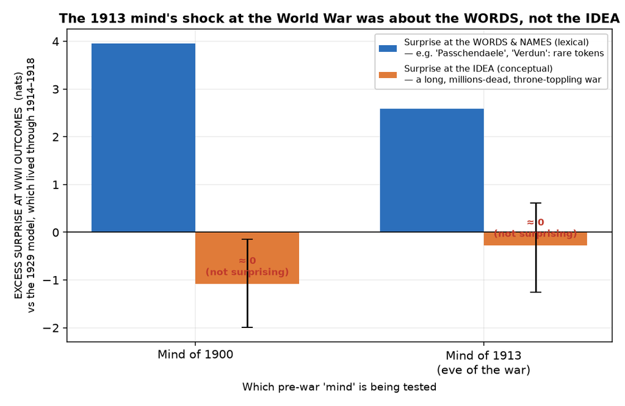

Benchmarked against the modern model, the same conclusion: WWI excess conceptual strain at 1929 is **+1.10 [+0.13, +2.02]** — down at the level of the timeless Tier-B controls (+1.25), far below the Depression.

### 3c · “Home by Christmas” was a mood, not a limit of imagination

For 8 duration/nature items we read the 1913 model’s probability on the *true* (long-war) outcome, $p_{\text{true}}$:

Six of eight lean to the true long war. Only the two **trench-deadlock tactics** items are wrong.

| forecast (true outcome) | $p_{\text{true}}$ (1913) | leans… |
| --- | --- | --- |
| “…marching into four years of slaughter” | 1.00 | TRUE |
| “…drag on for years, and bleed the nations white” | 1.00 | TRUE |
| “…come home only after long and bitter years” | 0.98 | TRUE |
| “…decided only after years of ruinous stalemate” | 0.87 | TRUE |
| “…pass their days dug into ditches in the earth” | 0.70 | TRUE |
| “…grind on for years despite the ruin” | 0.57 | TRUE |
| “…one of siege and deadlock, neither side able to move” | 0.04 | **wrong** |
| “…the gun in a fixed line, and the spade” | 0.03 | **wrong** |

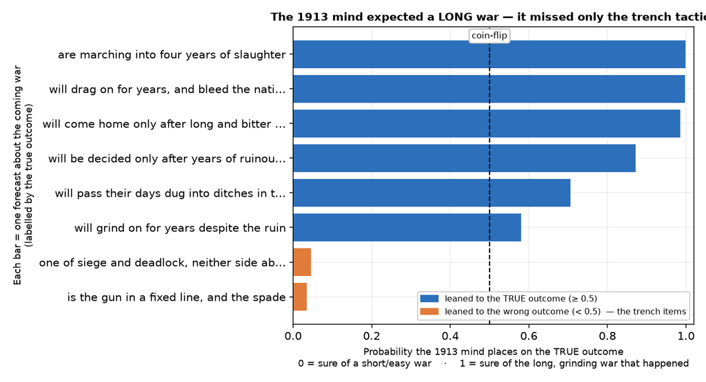

Figure 2: **Figure 2.** *The x-axis* shows the probability the 1913 mind places on the *true* outcome of each forecast (0 = sure of a short war, 1 = sure of the long war that happened; dashed line = coin-flip). *The y-axis* lists the forecasts; **blue** = the mind gets it right, **orange** = wrong. **Take-away:** the 1913 mind expected a long, costly war — it did *not* believe “home by Christmas”; it missed only the specific static-trench form.

The record it was trained on already contained the long war — Bloch (1899) had predicted attrition.

### 3d · Is the low surprise just cheating? The contamination gate

A low reading is foresight only if the mind isn’t peeking. We test the 1913 model on plain 1914–18 *facts* (chance = 25%): it scores **9/12 = 75% → “RED”**. But the item level shows a **place-name prior**, not knowledge:

It recognises 1914-era *words*, not *events* — exactly the lexical channel ($\Delta_{\text{lex}}$) we strip out.

| Gets RIGHT (famous *places/things* before 1914) | Gets WRONG (genuinely new after 1914) |
| --- | --- |
| Gallipoli, Jutland (a peninsula), Passchendaele, the Somme | the **“tank”** as a weapon (gap −7.52) |
| Versailles (a palace), the *Lusitania* (a 1906 liner) | the **1917 U.S. entry** |
| “Armistice year 1918” | even **Verdun** (its distractors were also fortress towns) |

**Status: robust.** WWI raw surprise is lexical ($\Delta_{\text{conc}}\approx 0$); the mind expected a long war; the gate signal is place-priors.

## 4 · Result 2 — the Great Depression: unforeseeable in the English bank (status now *open*, see §9b)

### 4a · High conceptual surprise at every cutoff, not falling toward the crash

Depression excess conceptual strain (XS) by cutoff: **1900 +3.60**, **1913 +2.84**, **1929 +3.53**. Even the 1929 mind, on the eve of the crash, is deeply strained — and the number does **not** fall as the cutoff nears the crash.

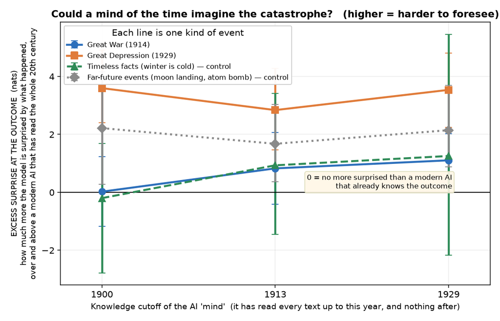

Figure 3: **Figure 3.** *The x-axis* shows the frozen mind’s cutoff year. *The y-axis measures* excess conceptual surprise (nats) vs a modern hindsight model (0 = no more surprised than a mind that saw it happen). The **orange Depression** line is high and flat; the **blue World War** line is low, among the **green timeless controls**; the **grey future-to-all** controls (moon, atom bomb) sit in between. **Take-away:** the Depression was harder to imagine, in advance, than the World War. (Absolute heights carry a cross-family offset; compare *lines at a fixed cutoff*.)

### 4b · “Less likely than the moon” — shown, not asserted

From §2 the “unforeseeable-to-all” benchmark at the 1929 mind is **moon +2.36**, whole set **+2.14**. The Depression’s mean XS at 1929 is **+3.53 > +2.36**, and its sharpest items are far above:

**Plainly:** to a mind that had read everything up to 1929, the *average* coming-Depression outcome was more conceptually surprising (+3.53) than a man walking on the moon (+2.36).

| Depression item (outcome) | XS (1929) | vs moon (+2.36) |
| --- | --- | --- |
| “buy rather more than before” *(the benign one)* | +8.30 | far above |
| “want, and hunger, and long idleness” | +7.42 | far above |
| “return only after long and bitter years” | +6.89 | far above |
| “a fourth of all who labour stand idle” | +5.69 | far above |
| “a peak from which they will presently crash” | +5.21 | far above |
| “choked by new walls of tariff” | +4.70 | above |
| “will fail by the thousand” | +4.40 | above |
| *(a few near zero: “sink into a slump” −0.04, “shake the governments” −0.57)* |  | mixed |

**Honest caveat.** Individual items are noisy and a few Depression items are near zero; this is a statement about the **averages**, and the moon benchmark (+2.36) is itself one noisy point. The statistically clean version is the contrast in §5.

### 4c · The gate says this is real, not cheating

The 1929 model on 1930+ Depression facts: **2/8 = 25% = pure chance** (binomial $p=0.63$) → **GREEN**. Even the two boundary probes on the October-1929 crash *itself* (“Black Thursday”, “the crash came in October”) are **both wrong (0/2)**. The eve-of-crash mind forecasts the whole Depression, crash included, from genuine ignorance.

### 4d · What the model expects instead

On the forced-choice probes the models lean to the *optimistic consensus*: Depression accuracy 38% (1929), 44% (1913), 25% (1900) — at or below chance for picking the true bad outcome over the rosy one. It expected prosperity to continue.

**Status: robust for the mean/contrast; the “vs moon” item comparison is suggestive given item noise.**

## 5 · The headline — Depression vs. World War, and why it survives the noise

The cleanest number is the **contrast** at the *same* model, which cancels any “modern model is just sharper” offset. Difference-in-differences at the 1929 model:

$$\text{DiD}=\text{XS}(\text{dep})-\text{XS}(\text{wwi})
=\underbrace{[\text{strain}_{1929}(\text{dep})-\text{strain}_{1929}(\text{wwi})]}_{\text{1929's own gap}}
-\underbrace{[\text{strain}_{\text{mod}}(\text{dep})-\text{strain}_{\text{mod}}(\text{wwi})]}_{\text{modern's own gap}}$$

The 1929 mind separates “the Depression is coming” from “a great war is coming” by far more than a mind that has read both endings does. Each strain is a model compared only to itself, so any modern offset cancels.

| step | value |
| --- | --- |
| 1929’s own gap (plateau vs millions-dead): $+0.12 - (-6.30)$ | **+6.42** |
| modern’s own gap: $-5.10 - (-7.77)$ | **+2.67** |
| DiD for this item pair | **+3.75** |
| **DiD averaged over all items** | **+2.43 nats, 95% CI [+0.80, +4.08], $p = 0.0026$** |

**Status: robust as a within-bank result — and, since v2, no longer the paper’s headline.** This contrast is offset-free by construction (each strain compares a model only to itself), so the +2-nat anchor problem of §9b does **not** touch it. But the v2 panel, using a different 12-item Depression battery, finds its own within-1929 contrast ≈ 0 — two banks, two answers. The Depression’s exceptionalism is therefore **item-set dependent and open** (§9b); this section is the strongest evidence on the “exceptional” side of that open question.

## 6 · Corroboration on real historical prose (Arm B)

Instead of our own sentences, we test the models on genuine published paragraphs. The first version of this section was flawed (one passage per cell, differenced only within the Ranke family, which could not tell “the Depression was surprising” apart from “Roosevelt writes more vividly than Hoover”). We rebuilt it two ways:

1. **Surprise is measured per character** (total $-\log P$ of the passage $/$ number of characters). Unlike surprise per *token*, per-character surprise is comparable *across tokenizers*, so the **modern model** can serve as the hindsight anchor here exactly as it does for the constructed probes.
2. **Three passages per cell from the *same* four authors** — Keynes (1919) and Angell (1910) for the war, F. D. Roosevelt (1933) and Hoover (1929) for the Depression — so writing style is held fixed, with a bootstrap over passages.

The quantity is $\text{XS}_{\text{text}} = \text{surprise}_{\text{pre-shock mind}} - \text{surprise}_{\text{modern mind}}$ on the same passage, and the headline is the **difference-in-differences**: post-shock prose minus the matched pre-shock control. Because the modern model has read both, the World War becomes its *own* control — it should give a DiD of about zero.

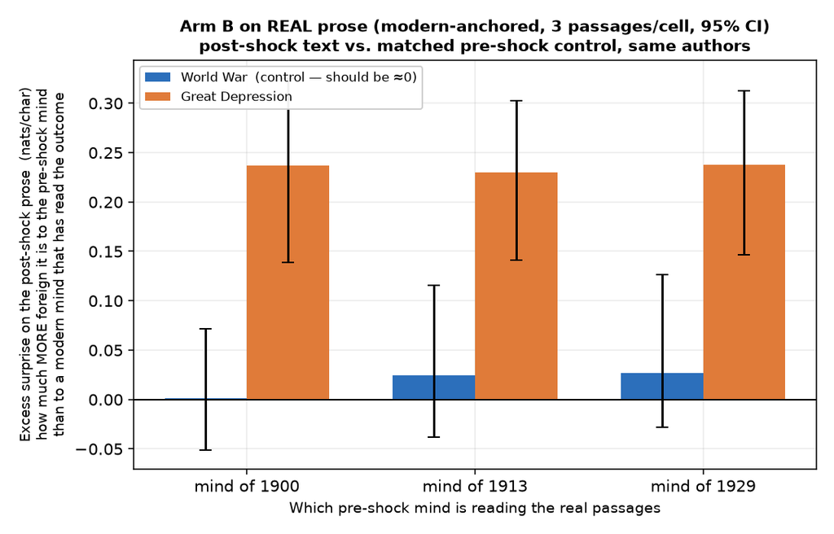

Modern-anchored, per-character, 3 passages/cell, bootstrapped. WWI passes its own null; the Depression signal is ~10× the WWI control and its CI clears zero everywhere.

| event | mind | DiD (post − pre) | 95% CI |
| --- | --- | --- | --- |
| **World War** (control) | 1913 | +0.024 | [−0.038, +0.116] |
| **World War** (control) | 1900 | +0.001 | [−0.052, +0.072] |
| **Great Depression** | 1929 (eve of crash) | **+0.237** | **[+0.147, +0.312]** |
| Great Depression | 1913 | +0.230 | [+0.141, +0.302] |
| Great Depression | 1900 | +0.236 | [+0.139, +0.325] |

This fixes the earlier confound directly: the modern model finds Hoover’s optimism (0.53 nats/char) and FDR’s “withered leaves” (0.51) about *equally* ordinary — it is not fooled by FDR’s vivid style, because it has read the Depression. So the signal is the pre-1930 minds’ excess over the modern mind on the post-shock text, which the pre-crash control confirms is about the *event*, not the *author*.

## 7 · Recognition vs. production (an honesty check, with its own caveat)

Two ways to read a mind: **recognition** = pick the more plausible of two endings (teacher-forcing); **production** = let it *freely write* and see what it volunteers. We generate 6 free continuations per item, code each by keyword markers, and take $\text{frac\_true}$ = fraction leaning true.

Recognition ≫ production — so any teacher-forced “inkling” is an upper bound (good for validity).

| mind | recognition (picks the true outcome) | production (volunteers it) |
| --- | --- | --- |
| 1900 | 62% | 0.23 |
| 1913 | **75%** | **0.19** |
| 1929 | 50% | 0.38 |

**But 0.19 is a skewed mean.** The 1913 per-item values are `[1.00, 0.17, 0, 0, 0, 0.33, 0, 0]` — one item at 1.00, five at 0.00:

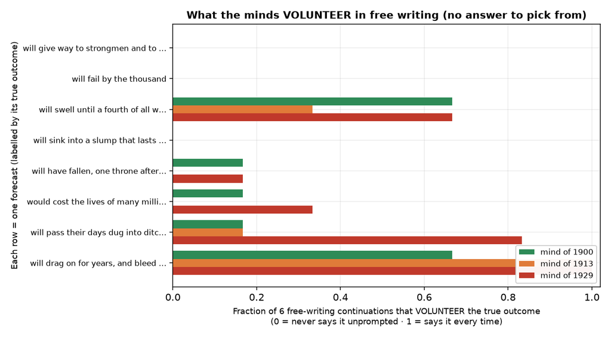

**Caveat.** On the items scored 0, the base model usually wanders **off-topic** rather than predicting the rosy outcome, so a 0 conflates “got it wrong” with “said something irrelevant”. Production is a crude floor, not a clean score — which is why recognition is the main read and production only a check that it isn’t inflating the signal.

## 8 · The pre-1914 worldview, in three languages (the Zweig probe)

Stefan Zweig’s memoir *The World of Yesterday* (1942) catalogues the pre-1914 mind — what he calls the “Golden Age of Security.” Because our models *are* frozen pre-1914 minds, we can ask directly whether they hold his beliefs. We test the **four themes he himself dwells on**: the faith in irresistible **progress**, the unthinkability of a European **war**, the confinement of **women**, and the veneration of age over **youth**.

**Design (v3, the full-strength battery).** Each theme now has **five** belief-vs-skeptic items (up from three), in **English, German and French**, scored by a **calibrated** preference: $c(a) = \log P(a\mid\text{period frame}) - \log P(a\mid\text{neutral frame})$, then $\text{belief\_pref} = c(\text{belief}) - c(\text{skeptic})$. The women’s items were rebuilt to be purely **normative** (“the age *held that* a woman’s place…”) — the earlier battery conflated what the age believed with what the age *was*, which the modern mind knows as history. Every stem and score is in `zweig_probe_v2.json`.

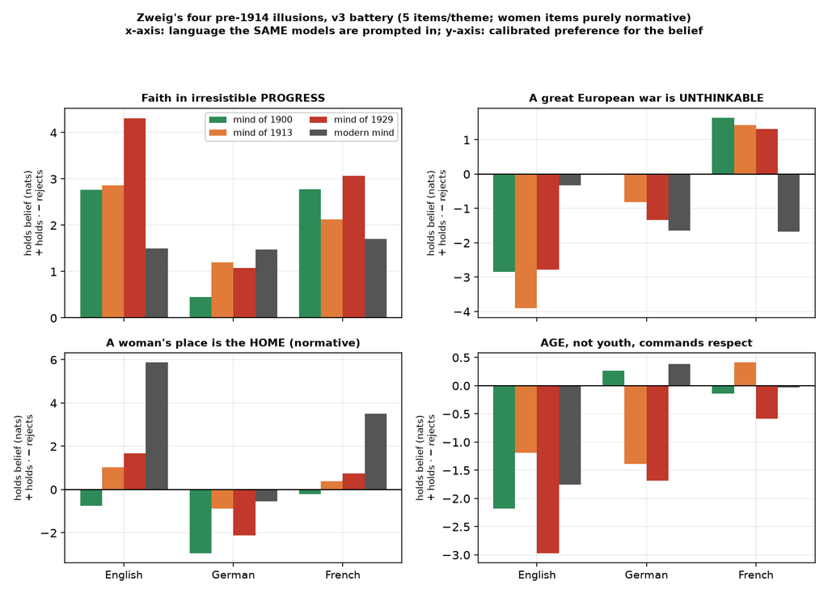

Figure 6: **Figure 9.** Each panel is one of Zweig’s four themes. *The x-axis* shows the language the same models are prompted in. *The y-axis measures* the calibrated preference for the pre-1914 belief over its opposite (nats; **+ = holds the illusion, − = rejects it**). Bars are the 1900/1913/1929 minds and a modern mind. **Take-away:** war-unthinkability is *French* (and rejected by the modern mind); the English mind expects war; progress is held everywhere but more weakly than the smaller battery suggested; women and youth do not register.

**What survives the bigger battery — and what shrinks.**

*Unthinkability of war* — the cleanest structure, and it sharpens: **English expects the war** at every cutoff (1913: −3.91), **French holds “war is unthinkable”** at every cutoff (1913: +1.42) and the modern mind rejects it (−1.68); **German, positive at three items, turns ambiguous at five** (1913: −0.82). Zweig’s “as impossible as witches and ghosts” survives measurement principally in his neighbours’ *French*.

+ = holds “war unthinkable”, − = expects war. French holds it; English expects it; German is battery-sensitive.

| “war is unthinkable” (v3) | 1900 | 1913 | 1929 | modern |
| --- | --- | --- | --- | --- |
| **English** | −2.85 | −3.91 | −2.79 | −0.33 |
| **German** | +0.02 | −0.82 | −1.33 | −1.65 |
| **French** | +1.64 | +1.42 | +1.32 | −1.68 |

*Faith in progress* — still positive at 1913 in every language (EN +2.86, DE +1.20, FR +2.12), but the time-locked-minus-modern gap shrinks with the battery (EN +1.4 at five items vs +4.7 at three). Held, but less spectacularly than the smaller battery suggested.

A subtlety worth stating: the same French mind that *rhetorically* holds war “unthinkable” is not conceptually surprised by the war’s concrete outcomes (§9). The unthinkability was a **stance, not a blindness**.

**The other two illusions stay holdouts — after the full nine yards.** With five purely normative items and rebuilt French twins, **women’s confinement** still reads as the *modern* mind’s historical knowledge (EN modern +5.87, FR modern +3.50) rather than a time-locked belief (1913: EN +1.03, DE −0.89, FR +0.37); **age over youth** still shows no signal anywhere (1913: EN −1.19, DE −1.39, FR +0.41). We report them as the measure’s limits, not as findings.

Progress held everywhere (more modestly than before); war French; women and youth null.

| the four themes, at the **1913** mind (v3) | progress | war | women | youth |
| --- | --- | --- | --- | --- |
| **English** | +2.86 | −3.91 | +1.03 | −1.19 |
| **German** | +1.20 | −0.82 | −0.89 | −1.39 |
| **French** | +2.12 | +1.42 | +0.37 | +0.41 |

*Take-away:* at full battery strength the models reproduce **two** of Zweig’s illusions in narrowed form — progress (all languages, modest) and the unthinkability of war (French, not Continental) — and cannot recover the other two. The battery-size sensitivity itself (German war flipped sign going from 3 to 5 items) is a caution we attach to all *worldview* probes; the *event* results of §9 are battery-robust (carryover items reproduce exactly).

## 9 · The panel: eight catastrophes, three languages, ranked

Everything through §6 uses the English item bank and two events. This section scales the design to its full potential: **eight catastrophes, 1907–1933**, each probed by **12 outcome statements in English, German and French**, each guarded by its own contamination gate, each duelled against equally dramatic counterfactuals that never happened. Pre-registered (`docs/PREREGISTRATION_FORESIGHT_v2.md`), screened, frozen with a hash. Every prompt and score is in `panel_events.html`, colour-coded.

**The estimator.** Six events have a **clean in-family anchor** — a later Ranke model that *read* the event (1913 anchors the 1907 panic; 1929 anchors the war, the imperial collapse, the Russian Revolution, the influenza pandemic, and the hyperinflation). For them, Δconc = strain(pre) − strain(anchor) is exact: shared tokenizer, vocabulary drift cancels token for token. The two post-1929 events (Depression, Nazi seizure) have no later Ranke model and must lean on the modern anchor — see the correction in §9b.

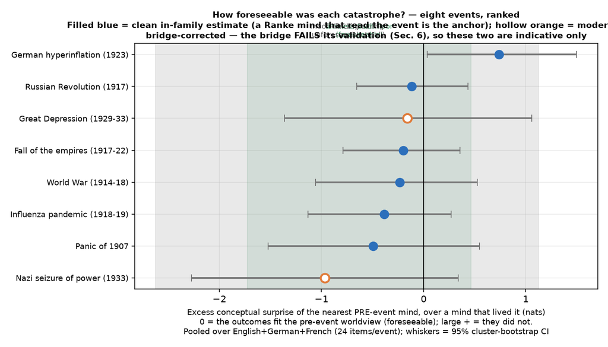

Figure 7: **Figure 7.** *The y-axis* lists the eight catastrophes; *the x-axis measures* the excess conceptual surprise of the nearest pre-event mind over a mind that lived through the event (nats), pooled over the three languages (24 items/event); whiskers = 95% cluster-bootstrap CIs. 0 = the outcomes fit the pre-event worldview (foreseeable); the green band is the timeless-truth floor, the grey band the moon-landing ceiling. **Filled blue** = clean in-family estimates; **hollow orange** (Depression, Nazi seizure) = modern-anchored, bridge-corrected — and the bridge fails its validation (§9b), so those two are indicative only. **Take-away:** panic, war, imperial collapse, revolution and pandemic were all *thinkable* in advance; the one in-family event above the floor is the hyperinflation — the death of money.

The full ranking (per-language columns from `stats_panel.json`; the two *bridged* rows are indicative only). Validation checks passed: the 1907 panic — included as a positive control, since financial panics were a recurring genre — reads at the floor; 24 items carried over verbatim from the earlier battery reproduce their scores exactly; the future-to-all controls read ≈ 0 *in-family* (the 1913 and 1929 minds are equally ignorant of the moon).

| Event (nearest pre mind → anchor) | pooled Δconc | 95% CI | English | German | French |
| --- | --- | --- | --- | --- | --- |
| Nazi seizure (1929 → modern, *bridged*) | −0.97 | [−2.27, +0.34] | +0.75 | −2.32 | −1.35 |
| Panic of 1907 (1900 → 1913) | −0.49 | [−1.52, +0.55] | −0.32 | −1.90 | +0.76 |
| Influenza pandemic (1913 → 1929) | −0.39 | [−1.13, +0.27] | −0.68 | −0.75 | +0.25 |
| World War (1913 → 1929) | −0.23 | [−1.06, +0.52] | −0.77 | −0.45 | +0.53 |
| Fall of the empires (1913 → 1929) | −0.20 | [−0.79, +0.36] | −0.72 | +0.15 | −0.03 |
| Great Depression (1929 → modern, *bridged*) | −0.16 | [−1.36, +1.06] | +0.55 | −1.66 | +0.63 |
| Russian Revolution (1913 → 1929) | −0.12 | [−0.66, +0.43] | −0.35 | +0.24 | −0.26 |
| **Hyperinflation (1913 → 1929)** | **+0.74** | **[+0.04, +1.50]** | −0.12 | +0.96 | **+1.39** |

**The one exception: the death of money.** The hyperinflation is the only in-family event whose pooled CI clears zero — and the honest fine print is that the signal is **French-led** (+1.39, permutation p = 0.006 against the French floor, the only event×language cell to survive the FDR correction), German-positive (+0.96), and **English-null** (−0.12). No single item drives it (max leave-one-out shift 0.46 nats). A conjecture, offered as such: the English record of 1913 was full of monetary ruin *as an argument* — assignats, greenbacks, free silver — while a French reader lived inside the franc germinal, unchanged since 1803. What a worldview can think is what its library kept arguing about.

**Do the minds point at the RIGHT catastrophes?** For each event, six matched duels: the true outcome vs an equally dramatic counterfactual that never happened, scored as a calibrated preference within the pre-event mind.

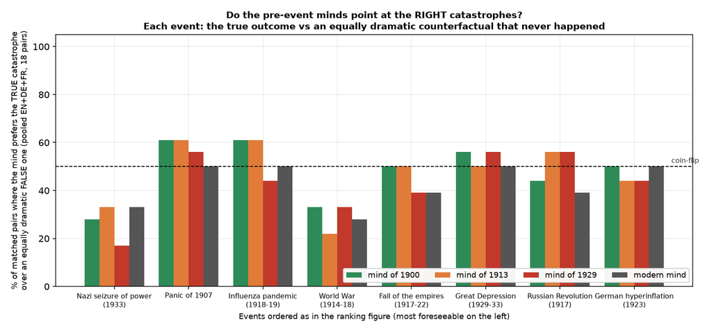

Figure 8: **Figure 8.** *The x-axis* lists the events (ordered as the ranking); *the y-axis measures* the share of matched true/false pairs where each mind prefers the TRUE catastrophe (pooled over languages, 18 pairs/event); dashed line = coin flip. Bars = the minds of 1900/1913/1929 and the modern mind. **Take-away:** the pre-event minds beat the coin where catastrophe was a recurring genre (the panic), flip coins on most events — and fall *below* the coin on the Nazi seizure: they prefer the paths history did not take.

- **Panic, 1900 mind: 61% true.** It knows the trust companies fall first (+2.72 nats) and that the crash will be severe (+1.72). Panics were its native genre.
- **Pandemic, 1913 mind: 61% true — split exactly along the thinkable.** It prefers “a form of the familiar influenza” over “the cholera come again” (+1.60) and places the pestilence in the last year of the war (+2.41); but it bets the disease will spare the young (−0.47) and that a serum will be found (−2.74). Form and timing: thinkable. The inverted mortality curve and the helplessness of medicine: not.
- **Nazi seizure, 1929 mind: 17% true — confidently wrong-footed.** Branch by branch it bets against the path history took: against lawful appointment, for the armed march (−2.75); against the corporal, for the generals restoring the Kaiser (−2.35); against the aged president appointing the man he despised (−2.29); against cheering crowds, for civil war (−4.15). The republic died by the one door its contemporaries had discounted.

**Free generation agrees, in the models’ own words.** The 1913 mind *volunteers* the Tsar’s deposition in 4/6 completions (“be deposed and his son made Emperor”); the 1900 mind volunteers suspended specie payments in 5/6. But prompted for the next world-sweeping pestilence, every mind names **cholera** (influenza: 0/6); prompted with a state on the printing press, none volunteers the death of the money; and asked *who* will rule Germany if the republic fails, the 1929 mind’s greedy answer is **“not yet in sight”** — four years before January 1933.

**The gates.** Seven of eight events gate GREEN under their pre-event mind (at chance on 6 post-event facts × 3 languages, flagged prior-trap items excluded); the hindsight anchors answer the same probes far above chance (WWI ceiling 14/15), validating the probes. The one AMBER — the revolution (9/18) — dissolves on inspection into a *Brest-Litovsk geography prior*: the 1913 mind aces the fortress-town question (3/3) while flooring on Lenin (0/3), the party (1/3), and the month (1/3); excluding that one item post hoc gives 6/15, p = 0.15, GREEN. The registered AMBER stands, and the caveat travels with the revolution’s reading.

### 9b · A correction: the modern anchor carries a two-nat offset (and our earlier claim is withdrawn)

The panel contains its own audit of cross-family comparisons, and the audit came back negative. Five events are *in* the 1929 corpus, so whatever excess the 1929 mind shows against the modern mind on outcomes it has **read** cannot be foresight failure — it is pure scale offset. Measured: **+1.96 nats (EN), +1.91 (DE), +1.06 (FR)**. The 1929 mind reads the World War — which it lived through — at +2.35/+2.13/+1.31 against the modern anchor. Two nats of what our earlier cross-lingual section (and the previous version of this walkthrough) called “the Depression’s unforeseeability in every language” was simply what *any* Ranke mind scores against a modern model.

The pre-registered bridge (subtract the offset, then demand the moon landing still read as unforeseeable) **fails its own validation** — after bridging, the future-to-all controls read +2.79 (EN) but −0.41 (DE) and +1.00 (FR) raw at the 1913 mind; the German failure traces to two control items whose archaic phrasing the modern model itself finds strained. Cross-family comparison confounds content with register. Consequently:

**Withdrawn:** our earlier three-language claim that the Great Depression was uniquely unforeseeable (+2.2/+2.0/+2.7 vs the modern mind at the 1929 model) was mostly scale offset, not foresight failure. **What survives:** the English-bank *within-model* contrast of §5 (+2.43 nats, p = 0.0026 — offset-free by construction) and its real-prose corroboration (§6). The panel’s own within-1929 contrast, built from different items, reads ≈ 0. Two banks, two answers: **the Depression’s unforeseeability is item-set dependent and remains open.** A Ranke model trained to ~1938 would anchor it in-family and settle it.

## 10 · Guards against artifacts

- **Drama bias:** 20 of 57 items are valence-balanced — the *true* outcome is the *less* dramatic one (real wages of the still-employed rose; no Kaiser restored; the great fleets sat idle). A measure that merely rewarded catastrophic language would fail these; the results hold.
- **Length bias:** the primary numbers are the horizon difference (same string, two models — length cancels) and calibrated scores (each option’s own baseline subtracted). The 28/57 exactly length-matched twins give the same ordering.
- **Blind screen + preregistration:** the 57-item bank was checked by two independent referees for historical accuracy and period authenticity, and locked before scoring.

## 11 · What is noisy or unresolved (limitations)

1. **Tier-B controls are a noisy null** (n=6, XS spread −4.98 to +10.89) — so we build no SD-unit effect sizes on them; the headline is the item-bootstrap contrast (§5).
2. **Item-level XS is noisy** for every battery; all headline claims are *averages* with bootstrap CIs, and the cleanest is the within-model DiD (§5). “Vs moon” (§4b) is a mean-level statement.
3. **The Depression and 1933 have no in-family anchor** — and §9b shows the modern-anchor bridge fails its validation, so both are *open*, not measured. A dedicated ~1938 model is the fix (**planned**).
4. **Base-model forced-choice is noisy** (timeless controls only 33–60%) — we lead with the continuous strain measures; the true/false duels lose power wherever the neutral frame retains the event identity (a design cost of calibration, documented per event in `panel_events.html`).
5. **Cross-family scale offset is ~+2 nats** (measured in §9b): only contrasts at a fixed model (§5) or in-family differences (§9) are offset-free; we never read an absolute XS against the modern model alone.
6. **Small models, modest batteries:** a null “no inkling detected” is an upper bound, not proof; and the panel’s one positive claim (hyperinflation) rests on 12 items per language, French-led, English-null.
7. **Zweig worldview holdouts (§8):** with five normative items and rebuilt French twins, **women** and **youth** still do not register as time-locked beliefs — reported as the measure’s limits. Worldview probes are also **battery-sensitive** (German war-unthinkability flipped sign from 3 to 5 items); event probes are not (carryover items reproduce exactly).
8. **The revolution’s gate is AMBER** (registered verdict) — driven by a Brest-Litovsk geography prior, GREEN in the post-hoc sensitivity — and the Nazi gate’s ceiling is weak (the modern 3B partly fails those probes), so that gate is less informative. Both caveats travel with the respective readings.

## 12 · Inventory of results

One line per result, tagged by how much weight it can bear.

| # | Result | Number | Status |
| --- | --- | --- | --- |
| C1 | Differencing null holds (future-to-all) | $\Delta S(1913)$ Tier-C = −0.45 [−0.99,+0.11] ≈ 0 | robust |
| C2 | Tier-C = unforeseeable benchmark | mean XS@1929 +2.14 (moon +2.36) | robust (noisy items) |
| W1 | WWI raw excess surprise | $\Delta S(1913)$ +2.30 [1.32,3.41] | robust |
| W2 | …is lexical, not conceptual | $\Delta_{\text{lex}}$ +2.58; **$\Delta_{\text{conc}}$ −0.28 [−1.25,+0.62]** | robust |
| W3 | WWI conceptual ≈ timeless controls | XS@1929 +1.10 [0.13,2.02] vs Tier-B +1.25 | robust |
| W4 | 1913 expected a long war | 6/8 items $p_{\text{true}}\ge0.5$; misses only trench | robust |
| W5 | WWI gate “RED” = place-prior | 75% on facts, but fails “tank”/1917-entry | robust |
| D1 | Depression conceptual surprise high, flat | XS 3.60 / 2.84 / 3.53 across cutoffs | robust |
| D2 | Depression > moon-class (mean) | 3.53 > Tier-C 2.14 (moon 2.36) | suggestive (item noise) |
| D3 | 1929 clean on Depression | gate 2/8=25% p=0.63; crash itself 0/2 | robust |
| D4 | Models expect the optimistic consensus | forced-choice 25–44% | supportive |
| **H** | **Headline: Dep − WWI at 1929** | **DiD +2.43 [0.80,4.08], p=0.0026** | **robust** |
| B1 | Real prose, WWI (modern-anchored, powered) | DiD +0.02 [−0.04,+0.12] ≈ 0 (own control) | robust |
| B2 | Real prose, Depression (modern-anchored) | DiD +0.24 [+0.15,+0.31] @1929; ~10× WWI | robust |
| P1 | Recognition ≫ production | 75%→0.19 (1913), skewed; war-duration 1.00 | supportive, crude |
| Z1 | Zweig v3: faith in progress (5 items) | 1913 EN/DE/FR +2.9 / +1.2 / +2.1; gap to modern shrinks | robust, modest |
| Z2 | Zweig v3: “war unthinkable” is FRENCH | 1913: EN −3.9 (expects war), DE −0.8, FR +1.4; modern rejects | robust (DE battery-sensitive) |
| Z3 | Zweig v3: women & youth (5 normative items) | women = modern hindsight (EN mod +5.9); youth null | holdout |
| **P1** | **Panel: 5 in-family events foreseeable, 3 langs** | panic −0.49, flu −0.39, WWI −0.23, empires −0.20, revolution −0.12; all CIs straddle 0 | **robust, gated** |
| **P2** | **Panel: hyperinflation the one exception** | pooled +0.74 [+0.04,+1.50]; FR +1.39 p=.006 (sole FDR survivor); EN −0.12 | **robust; French-led** |
| P3 | Panel: true/false duels — selection failed | panic 61% true; flu 61% (form/timing right, age/serum wrong); nazi **17%** (bets on putsch/Kaiser/soviets) | robust, offset-free |
| P4 | Panel: free generation | Tsar deposed 4/6 volunteered; influenza 0/6 (cholera!); mark’s death 0/6; “who rules Germany” → *“not yet in sight”* | supportive |
| P5 | Panel gates | 7/8 GREEN; revolution AMBER = Brest-Litovsk geography prior (post-hoc GREEN 6/15 p=.15) | robust |
| **P6** | **Bridge audit: modern anchor carries +2 nats offset** | offset EN/DE/FR +1.96/+1.91/+1.06; even in-sample WWI reads +2.35 vs modern at the 1929 mind; Tier-C tripwire fires in DE | **robust — a correction** |
| P7 | **WITHDRAWN**: “Depression unforeseeable in all 3 languages” | old XS +2.2/+2.0/+2.7 ≈ the offset; bridged ≈ 0 with wide CIs | withdrawn |
| L1 | Depression’s status after the panel | English-bank DiD +2.43 (offset-free) vs panel within-1929 ≈ 0 — item-set dependent | **open** (needs 1938 model) |
| L2 | Nazi seizure Δconc | bridged −0.97 (indicative only); but its T/F duels (P3) are offset-free and decisive | duels robust; level open |

**Bottom line.** The catastrophes of the early twentieth century were not bolts from a clear sky. Panic, world war, the fall of the empires, revolution, and a world-circling pandemic all fit the pre-event worldview as comfortably as timeless truths — in English, German, and French, with the gates certifying that the minds did not know the facts. The one in-family exception is the **death of money** (French-led). What failed was not imagination but **selection**: the same minds that volunteer a deposed Tsar expect cholera rather than influenza, sound money rather than trillion-mark bread, and a putsch, the generals, or the soviets rather than the lawful appointment that actually killed the republic — **17% against a coin flip**. And one methodological result we did not want but must keep: the modern anchor carries a **two-nat scale offset** that manufactured our own earlier three-language Depression claim, which we withdraw; the Depression’s exceptionalism now rests on one offset-free English contrast (+2.43, p=0.003) that the panel neither confirms nor refutes — open until a 1938 model exists. The futures were on the shelf; contemporaries picked the wrong ones.

## 13 · How to reproduce

All numbers above are computed by scripts in `src/` (nothing hand-entered), run in the `timelock-contamination` venv with `PYTHONUTF8=1`, from the repo root:

```
# v1 English bank (§1–§7)
src/preflight.py → src/freeze.py → src/score_all.py → src/stats.py → src/gate.py
src/text_perplexity.py   (Arm B)          src/production.py       (recognition vs generation)

# v2 panel (§8–§9)
src/panel_bank.py        (screen + freeze, SHA-256)
src/gate_panel.py        (gates first — integrity before results)
src/score_panel.py       (8 events × 12 items × 3 langs + controls + true/false, all 4 minds)
src/stats_panel.py       (bootstrap, cluster bootstrap, permutation, FDR, bridge, LOO)
src/production_panel.py  (free generation, new events)
src/zweig_probe.py       (v3 worldview battery)

# outputs
src/build_panel_report.py + src/build_foresight_report.py   (figures + transparent HTMLs)
src/make_numbers.py      (225 auto-generated macros + tables)   quarto render reports/walkthrough.qmd
```

Result files in `results/`: `question_bank_panel.json` (frozen bank + hash), `panel_scores.json`, `stats_panel.json`, `gate_panel.json`, `production_panel.json`, `zweig_probe_v2.json`, plus the v1 files; transparent item-by-item reports in `reports/panel_events.html`; real source texts under `passages/` and `zweig/`.